# IODS course project

```r
as.data.frame(boston_scaled) -> boston_scaled
bins <- quantile(boston_scaled$crim)
crime <- cut(boston_scaled$crim, breaks = bins, include.lowest = TRUE, label = c("low", "med_low", "med_high", "high"))
boston_scaled <- dplyr::select(boston_scaled, -crim)
boston_scaled <- data.frame(boston_scaled, crime)
n <- nrow(boston_scaled)
ind <- sample(n,  size = n * 0.8)
train <- boston_scaled[ind,]
test <- boston_scaled[-ind,]
```

Linear discriminant analysis (LDA) was fit onto the training dataset using the lda() function, based on the categorical crime variable versus all other variables (indicated by the ~). The lda analysis was plotted including a function for arrows. LDA is used for dimension reduction and classification. It basically seeks to separate the variables as compared to the target variable “crime”.

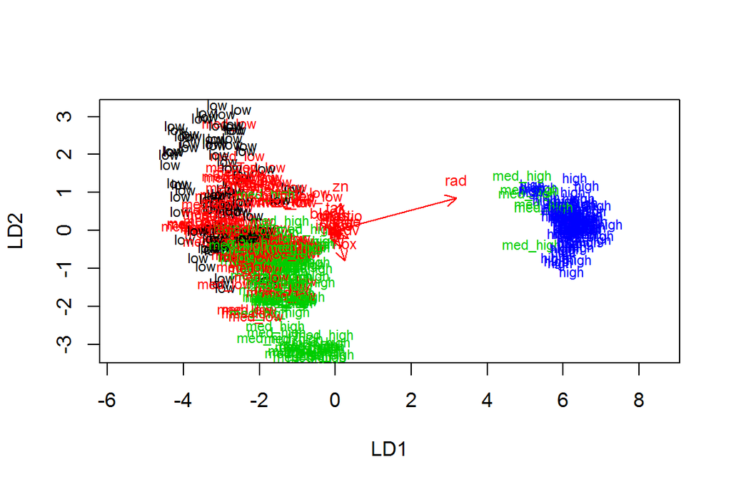

```r
lda.fit <- lda(crime~., data = train)
lda.arrows <- function(x, myscale = 1, arrow_heads = 0.1, color = "red", tex = 0.75, choices = c(1,2)){
  heads <- coef(x)
  arrows(x0 = 0, y0 = 0,
         x1 = myscale * heads[,choices[1]],
         y1 = myscale * heads[,choices[2]], col=color, length = arrow_heads)
  text(myscale * heads[,choices], labels = row.names(heads),
       cex = tex, col=color, pos=3)
}
classes <- as.numeric(train$crime)
plot(lda.fit, dimen = 2, col = classes, pch= classes)
lda.arrows(lda.fit, myscale = 1)
```

The original “crime” values from the test dataset were saved to a new variable called test_classes, and the variable deleted from the dataset. The LDA model from the previous step was used in conjunction with the predict() function to generate predicted values, and these were shown in a table versus the real values. The model was reasonably good at predicting the correct crime category.

```r
test_classes <- test$crime
test <- dplyr::select(test, -crime)
lda.pred <- predict(lda.fit, newdata = test)
table(correct = test_classes, predicted = lda.pred$class)
```

```
##           predicted
## correct    low med_low med_high high
##   low       16      12        4    0
##   med_low    2      16        6    0
##   med_high   0       4       10    0
##   high       0       0        1   31
```

The Boston dataset variables were scaled, and both the Euclidean and Manhattan distances were calculated. These show how far the variables are from one another, using two different measurements, and are one component of the k-means clustering algorithm. Based on the plot of the twcss function, it is apparent that the optimal number of clusters is around 2, as this is the point at which the data starts to vary. These clusters were plotted using the pairs function for all variables, which is slightly hard to interpret.

```r
library(MASS)
library(GGally)
data(Boston)
boston_scaled <- scale(Boston)
dist_eu <- dist(boston_scaled)
"Euclidean distance"
```

```
## [1] "Euclidean distance"
```

```r
summary(dist_eu)
```

```
##    Min. 1st Qu.  Median    Mean 3rd Qu.    Max.
##  0.1343  3.4620  4.8240  4.9110  6.1860 14.4000
```

```r
dist_man <- dist(boston_scaled, method ="manhattan")
"Manhattan distance"
```

```
## [1] "Manhattan distance"
```

```r
summary(dist_man)
```

```
##    Min. 1st Qu.  Median    Mean 3rd Qu.    Max.
##  0.2662  8.4830 12.6100 13.5500 17.7600 48.8600
```

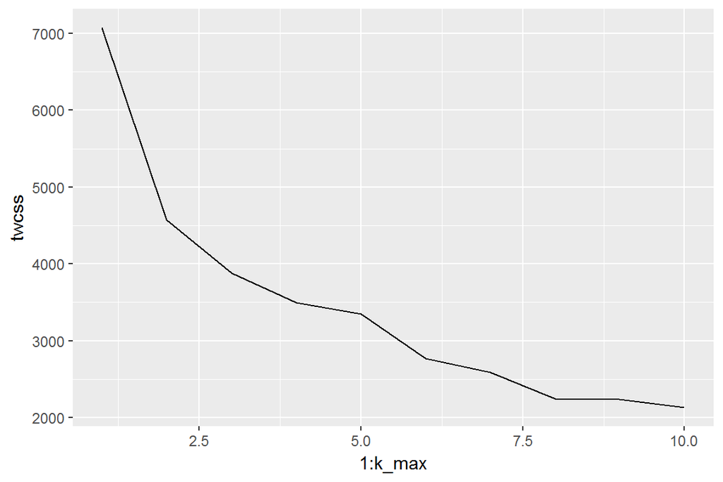

```r
k_max <- 10
twcss <- sapply(1:k_max, function(k){kmeans(boston_scaled, k)$tot.withinss})
qplot(x = 1:k_max, y = twcss, geom = 'line')
```

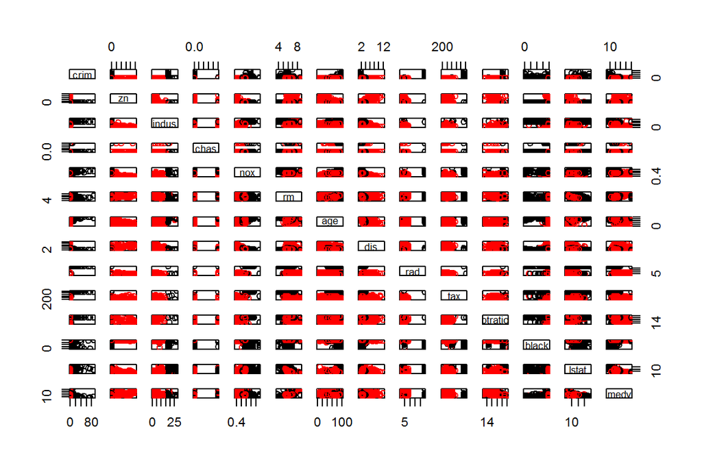

```r
km <-kmeans(boston_scaled, centers = 2)
pairs(Boston, col = km$cluster)
```